# Ageing impact in gene expression on skeletal muscle repair

PrepareData report

Team Le Grand

29 juillet,2022

# I.Data origine (Mus musculus - tibialis anterior muscle)

In order to explore cell expression during muscle regeneration in young(2-3 months) and old(18-22 months) cells, RNAseq experiments (paired end 120pb illumina) were performed using cells sorted and FACs at four time points:

- D0 muscles without injury
- D2, 2 days after cardiotoxin-induced injury
- D4, 4 days after injury
- D7, 7 days after injury

The cell types sampled were as follows:

- D0 , Endothelial Cells ECs, FibroAdipogenic Progenitors - FAPs, Muscle Stem Cells MuSCs.
- D2 , ECs, FAPs, MuSCs., Neutrophile Cells, Inflammatory Macrophages - Inflammatory-Mac and Resolving Macrophages - Resolving-Mac .
- D4, ECs, FAPs, MuSCs, Inflammatory-Mac, Resolving-Mac
- D7, ECs, FAPs, MuSCs, Resolving-Mac

# I.1 Pretreatment RNA-seq data with pipeline nfcore/rnaseq (v.1.4.2)

The RNA-seq data is aligned to the GRCm38 genome with STAR and counted with FeatureCount .

Quality report of alignement in multiQc

# Summary of scripts

##get_expre_to_csv_rdf.R:

Merge gene_counts files by batch then in one file : **geneID_samp_matrix.rds** (rawcount expression matrix), Keep info batch - sample_name in batchesinfo.csv Keep info Geneid - GeneName in genesinfo.csv Merge StringtieFPKM_gene_abund_all_batch in three files , **TPMmatrix.cvs** , COVmatrix.csv and FTPMmatrix.csv

##get_biotypes_bulk.R :

Use ENSEMBL_MART_ENSEMBL database to associated gene name with biotype, if discordante information in function strain, keep canonical. For gene without biotype attribution (52382 on 55487) , try with other mouse strain in mart database and annotationdbi EnsDb.Mmusculus.v79 (55250 on 55487) Final file **biotype_bulk.csv**

##get_protcod_TPMandCounts.R:

Keep only protein coding biotype.

```
## protein_coding
##          21930
```

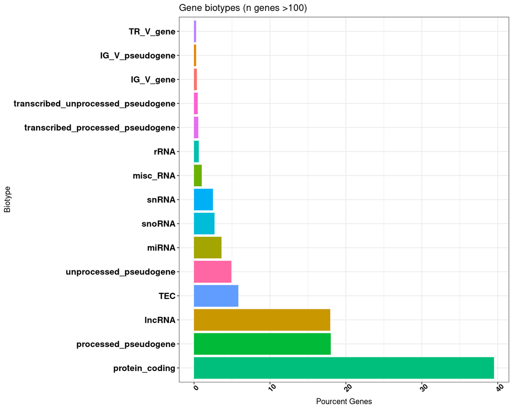

##libraries_kept_andPCA.R Remove transcrits associated with genes witch have same symbol (36 genes), filter out all-zeroes rows (2289 genes). Retain only good quality libraries (8 libraries excluded)

# Explore correlation between sample

## Spearman correlation

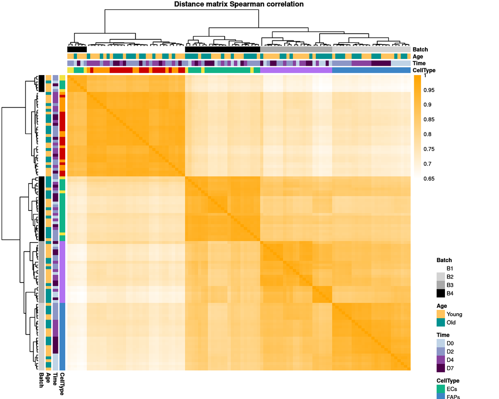

## PCA

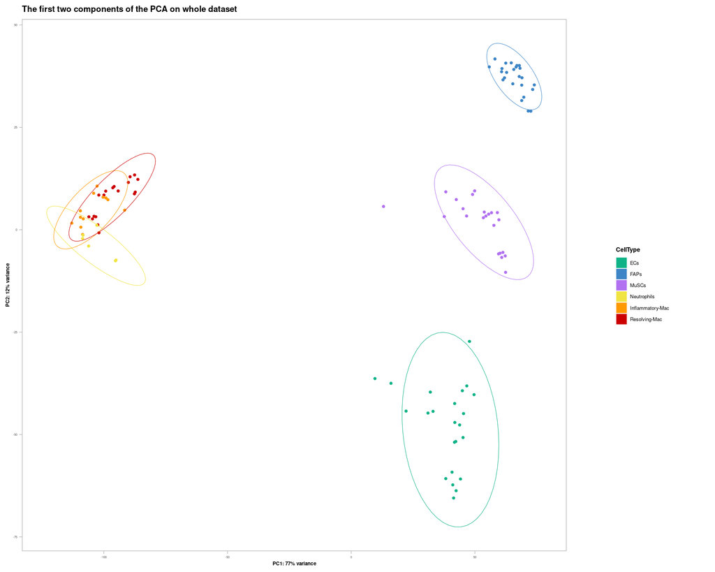

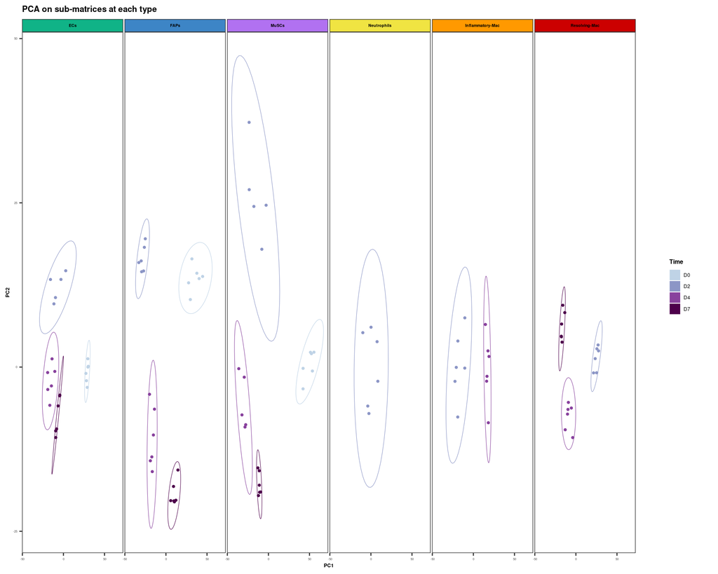

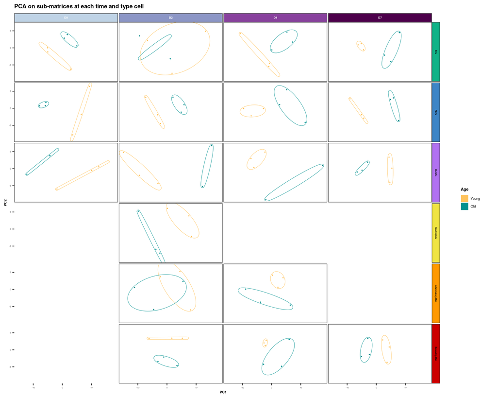